# Medidas de tendencia central 🤖

[Jahaziel Shamed Uribe Salguero](https://github.com/UribeJahaziel)

Estadística 2022-2, [Facultad de economía](http://www.economia.unam.mx/)

2/3/2022

### 1. ¿Qué son las medidas de tendencia central? 🤔

> “**Las medidas de tendencia central** son valores numéricos que tienden a localizar la parte central de un conjunto de datos. Cada una de ellas ofrece un centro de la distribución de frecuencias, lo que implica que representa un valor que se puede tomar como representativo de todos los datos. Hay diferentes modos para definir el centro de las observaciones en un conjunto de datos. A continuación, se presentan los más usados.”

[Prepa 8 UNAM (2022)](http://prepa8.unam.mx/academia/colegios/matematicas/paginacolmate/applets/matematicas_IV/Applets_Geogebra/medtencen.html)

Para este ejemplo, primero generaremos una serie de **100** números aleatorios entre **1** y **20** mediante la función `sample`. El argumento `TRUE` nos permitirá generar una muestra con remplazo:

```r
numeros <- sample(1:20, 100, TRUE)
numeros
```

```
##   [1]  5  3 18  4  4 15 20 17 10  8  3 16  5 15  1  7  2  3  1  2 17  7 16 14  9
##  [26]  6 14 10 14  2 10  1 10  8  8 15  2 10 18 10 15  1 17 14 19 11  6 12  8  6
##  [51] 15  5  4 11 14 19 12  2  4 13 18 20 13 12 20 11  6 20 17 17  9  6  4  1  2
##  [76]  9 10 15  7 19 17  7 12 15 18  1 20  8  2 19  9  6 18  2 13  6 12 10  6 14
```

### 2. Mediana 📍

> “La **mediana** es el valor que ocupa el lugar central de todos los datos cuando éstos están ordenados de menor a mayor.”

[Superprof(2020)](https://www.superprof.es/apuntes/escolar/matematicas/estadistica/descriptiva/mediana.html)

Para obtener la **mediana**, podemos ordenar los `numeros` de menor a mayor, **el número que esté en medio de la muestra será la mediana**. Si utilizamos R, se puede hacer el cálculo de la **mediana** con la función `median`:

```r
mediana <- median(numeros)
mediana
```

```
## [1] 10
```

### 3. Media 🧮

> “La **media** es el valor promedio de un conjunto de datos numéricos, calculada como la suma del conjunto de valores dividida entre el número total de valores. La **media**, a diferencia de la esperanza matemática, es un término matemático.”

[Economipedia(2018)](https://economipedia.com/definiciones/media.html#:~:text=La%20media%20es%20el%20valor,matem%C3%A1tica%2C%20es%20un%20t%C3%A9rmino%20matem%C3%A1tico.)

$$Media ={\frac {1}{n}}\sum _{i=1}^{n}a_{i}={\frac {a_{1}+a_{2}+\cdots +a_{n}}{n}}$$

Si usamos R, podemos obtener la media de una muestra si utlilizamos la función **mean**:

```r
media <- mean(numeros)
media
```

```
## [1] 10.19
```

### 4. Moda 📊

> “La **moda** es el valor que aparece más dentro de un conglomerado. En un grupo puede haber dos modas y se conoce como bimodal, y más de dos modas o multimodal cuando se repiten más de dos valores; se llama amodal cuando en un conglomerado no se repiten los valores.”

> [QuestionPro(2019)](https://www.questionpro.com/blog/es/la-media-la-mediana-y-la-moda/)

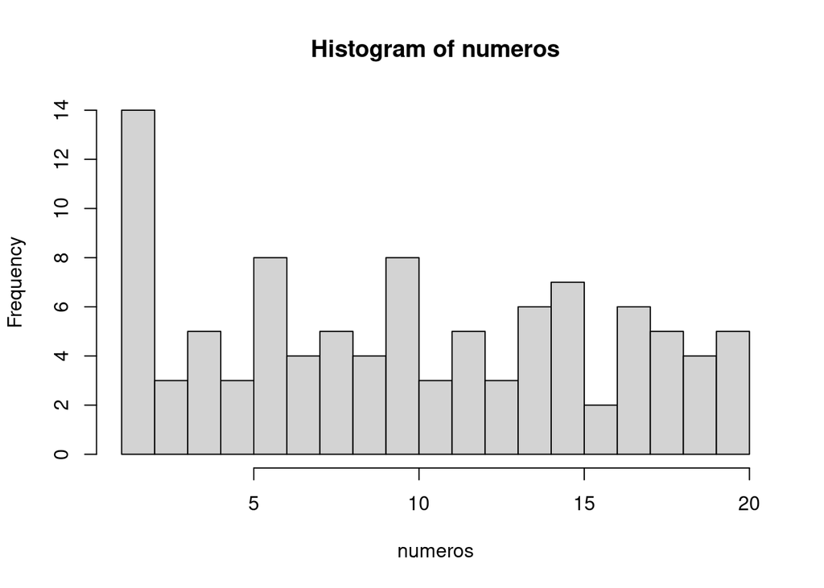

```r
# El argumento breaks nos permite dividir en histograma en las partes que queramos
hist(numeros, breaks = 20)
```

Para obtener un resultado con más precisión, podemos obtener la **moda** si generamos una **tabla de frecuencias** con la función `table` y la función `data.frame`, **aquel elemento con mayor frecuencia será la moda**:

```r
tabla.frecuencias <- data.frame(table(numeros))
tabla.frecuencias
```

```
##    numeros Freq
## 1        1    6
## 2        2    8
## 3        3    3
## 4        4    5
## 5        5    3
## 6        6    8
## 7        7    4
## 8        8    5
## 9        9    4
## 10      10    8
## 11      11    3
## 12      12    5
## 13      13    3
## 14      14    6
## 15      15    7
## 16      16    2
## 17      17    6
## 18      18    5
## 19      19    4
## 20      20    5
```

### 5. Ejercicio 👩‍💻👨‍💻✍

Aplica lo que aprendiste, obten la **mediana**, **media** y **moda** de la siguiente muestra de números:

```r
# Con la función seq, creamos una secuencia de 1 a 10 en intervalos de 0.1 en 0.1
secuencia <- seq(1, 10, 0.1)
muestra <- sample(secuencia, 100, TRUE)
muestra
```

```
##   [1]  4.0  3.8  1.6  3.0  2.8  2.5  1.7  7.7  6.2  3.1  9.6  1.0  7.0  5.6  8.2
##  [16]  6.4  8.9  2.2  4.5  2.7  5.9  7.7  6.5  5.1  3.8  5.1  6.5  2.7  7.7  2.0
##  [31]  7.2  6.7  7.5  5.2  9.2 10.0  3.4  7.8  6.6  1.8  6.7  1.1  5.2  9.5  6.9
##  [46]  1.6  3.1  4.5  1.2  9.8  1.4  6.6  3.3  2.0  3.3  8.9  1.6  2.5  6.5  1.4
##  [61]  1.3  3.8  2.9  2.3  8.5  1.2  8.9  7.8  8.8  3.6  2.9  4.9  4.2  9.5  1.8
##  [76]  2.7  2.9  2.6  7.7  3.7  9.9  9.9  1.0  9.8  7.9  1.6  9.7  5.1  3.9  1.4
##  [91]  2.4  3.4  7.6  8.7  3.0  5.3  7.7  7.9  4.7  6.8
```

##### Mediana

```r
# Aquí el cálculo de la mediana
mediana.muestra <-median(muestra)
mediana.muestra
```

```
## [1] 4.8
```

##### Media

```r
# Aquí el cálculo de la media
media.muestra <- mean(muestra)
media.muestra
```

```
## [1] 5.077
```

##### Moda

```r
# Aquí el cálculo de la moda
tabla.muestra <- data.frame(table(muestra))
tabla.muestra
```

```
##    muestra Freq
## 1        1    2
## 2      1.1    1
## 3      1.2    2
## 4      1.3    1
## 5      1.4    3
## 6      1.6    4
## 7      1.7    1
## 8      1.8    2
## 9        2    2
## 10     2.2    1
## 11     2.3    1
## 12     2.4    1
## 13     2.5    2
## 14     2.6    1
```

[output cut: 47 more lines]

```r
tabla.muestra
```

```
##    muestra Freq
## 1        1    2
## 2      1.1    1
## 3      1.2    2
## 4      1.3    1
## 5      1.4    3
## 6      1.6    4
## 7      1.7    1
## 8      1.8    2
## 9        2    2
## 10     2.2    1
## 11     2.3    1
## 12     2.4    1
## 13     2.5    2
## 14     2.6    1
```

[output cut: 47 more lines]

💻[Código disponible en RStudio Cloud](https://rstudio.cloud/project/3671022)💻